[figure not shown]

# presentation

# R Workshop

### Module 1: Introduction to R

2018-01-01  
Bobae Kang  
(Bobae.Kang@illinois.gov)

## Introduction to the Workshop

[figure not shown]

### Instructor (me!)

[figure not shown]

### Workshop objectives

> This workshop will help YOU **to get started** and provide them with the basic skills and techniques in using R for research and data analysis.

> Ultimately, this workshop seeks to help YOU **to gain the knowledge and confidence necesary to learn** what they need to know for their own research projects.
- Import and manipulate tabular data files using R;
- Create simple data visualizations (scatterplot, histogram, bar chart, line chart, etc.) to extract insight from data using R;
- Perform basic statistical analysis using R;
- Generate a report on a simple data analysis task using R;
- Understand the basic elements of the R programming language;
- Employ the programmatic approach to research and data analysis projects; and
- Leverage online resources to find solutions to specific questions on using R for a given task.

### A programming approach to research

[figure not shown]

Source: [pixabay.com](https://pixabay.com/en/code-geek-talk-code-to-me-coffee-cup-2680204/)

## Introducing ... R!

[output not shown]

### What is R?

> “R is a language and environment for statistical computing and graphics.” - The R Foundation
- *Built for* data analysis and visualization
- One of the the most popular choices of programming language among academic researchers and data scientists

[figure not shown]

Source: David Robinson, 2017, [“The Impresseive Growth of R”](https://stackoverflow.blog/2017/10/10/impressive-growth-r/)

### Why R?

[figure not shown]

Source: [flickr.com](https://www.flickr.com/)

(Because … DUH!)

[figure not shown]

Source: [Reaction GIFs](https://www.reactiongifs.com/)

### And more reasons

- Open source (free!)
- Built for statistical analysis
- Reproducible and transparent
- Extensible through powerful third-party libraries
- Enabling researchers to tackle a variety of tasks using a *single* platform

## Comparisons

### R vs Excel

- License cost
- Speed
- Scalability
- Complex and advanced analysis
- Visualization

### R vs SPSS

- License cost (again)
- Syntax
- Visualization
- Presentation

### R vs Tableau

- License cost (DUH!)
- Cleaning data
- Complex and advanced analysis

### What is RStudio? Why use it?

- Best Integrated Development Environment (IDE) for R
- Powerful and convenient features
- Interactive workflow
- Open source (again!)
- … and many more!

[figure not shown]

Source: [Wikimedia.org](https://www.wikimedia.org//)

## Basic Setup

[figure not shown]

Source: [Wikimedia.org](https://www.wikimedia.org//)

### Installing R

- Visit https://cran.r-project.org/
- Or simply google “download R” to find the link to download page.
- *Installation requires the Administrator account*; talk to DoIT!

[figure not shown]

[figure not shown]

[figure not shown]

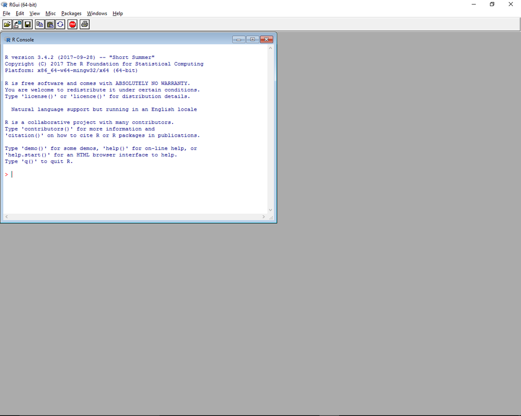

### Installing RStudio

- Visit https://www.rstudio.com/products/rstudio/download/
- Or simply google “download Rstudio” to find the link to download page.
- Agin, *installation requires the Administrator account*; talk to DoIT!

[figure not shown]

[figure not shown]

[figure not shown]

## Workshop Overview

[figure not shown]

Source: [Wikimedia.org](https://www.wikimedia.org//)

### Module 2

## R basics

- Fundamental building blocks of R programming.
- Libraries and packages
- `tidyverse` framework
- Recommended R style guide

### Module 3

## Data manipulation

- Importing/exporting data
- Essential `dpylr` and `tidyr` commends
- Working with character strings
- Working with `Date` objects

### Module 4

## Data visualization

- Base R plots
- `ggplot2` package
- Plotting maps
- Interactive plots

### Module 5

## Statistical analysis

### Module 6

## Presentations and beyond

- R Markdown and R Notebook
- R Presentation and `ioslides`
- Shiny applications
- … and more!

## Questions?

[figure not shown]

Source: [tenor.com](https://tenor.com/view/beyonce-question-gif-5966034)